# Untitled

```r
library(tidyverse)
library(RColorBrewer)
library(gplots)

library(randomForest)
library(broom) # create dataframe from statistical tests outputs
library(gridExtra) # to save ggplots on 1 page

# library(plyr) # to round up to tearest 10; problem with some dplyr comands

library(rtracklayer)
library(Biostrings)
library(GenomicRanges)

source("~/Work/2019/Analysis/Utilities_R/Functions/My_functions.R")

set.seed(100)
```

```r
load("data/data_to_load/Brapa_promoters_analysis_distance_short.RData")
```

```r
head(Brapa3_TF_results_homoeolog)
```

```
##   promoter_width          gene_id strand                          motif
## 1           1500 BraA01g000050.3C      + ABI3VP1_tnt.AT5G25475_col_a_m1
## 2           1500 BraA01g000050.3C      +      ABI3VP1_tnt.NGA4_col_a_m1
## 3           1500 BraA01g000050.3C      +   AP2EREBP_tnt.RAP211_col_a_m1
## 4           1500 BraA01g000050.3C      + AP2EREBP_tnt.RAP26_colamp_a_d1
## 5           1500 BraA01g000050.3C      +        ARF_tnt.ARF2_col_v31_m1
## 6           1500 BraA01g000050.3C      + ARID_tnt.At1g76110_colamp_a_m1
##   start stop  score max.score score.pct            match    TF_family
## 1  1028 1033 11.907  11.90858  99.98676           CAAGCA  ABI3VP1_tnt
## 2    18   33 11.890  18.95735  62.71975 AATTTTCAGATGAATT  ABI3VP1_tnt
## 3   485  499 12.688  17.78343  71.34733  CCATCGTGGCCGCCG AP2EREBP_tnt
## 4   931  936  8.929  10.69058  83.52216           AGCCGC AP2EREBP_tnt
## 5    73   82  8.462  13.63393  62.06573       GAGAGACAAG      ARF_tnt
## 6  1065 1079  9.572  14.80052  64.67340  ATGCGAAATTAAATT     ARID_tnt
##      V1       AGI Genome homoeolog distance_to_TSS
## 1 18133 AT4G38210      U         1             473
## 2 18133 AT4G38210      U         1            1483
## 3 18133 AT4G38210      U         1            1016
## 4 18133 AT4G38210      U         1             570
## 5 18133 AT4G38210      U         1            1428
## 6 18133 AT4G38210      U         1             436
```

```r
head(TF_family)
```

```
## [1] "ABI3VP1_tnt"  "AP2EREBP_tnt" "ARF_tnt"      "ARID_tnt"
## [5] "bHLH_tnt"     "bZIP_tnt"
```

# Plot distribution of max.scores of TF within the family

```r
plot_1 <-lapply(TF_family, function(x)
   Brapa3_TF_results_homoeolog %>%
  filter(TF_family == x) %>%
  ggplot(aes(x = motif, y = max.score)) +
  geom_boxplot() +
  scale_y_continuous(limits = c(0, 70)) +
   labs(title = x) +
   theme_minimal() +
   theme(legend.position = "none")
   )


j <- 1
k <- 16
 for (i in 1:4){
   if (k < length(TF_family)){
  ggsave(paste0("Plots/Brapa_promoters_analysis_distance/Brapa_distance_to_TSS_vs_TF_maxscore_by_families", i, ".jpg"),
         marrangeGrob(grobs = plot_1[j:k], nrow=4, ncol=4))
 j <- j+16
 k <- k + 16
   } else {ggsave(paste0("Plots/Brapa_promoters_analysis_distance/Brapa_distance_to_TSS_vs_TF_maxscore_by_families", i, ".jpg"),
                  marrangeGrob(grobs = plot_1[j:length(TF_family)], nrow=4, ncol=4))
 }
}


rm("j", "k", "i")

# rm(list = c(str_subset(ls(), "test|plot|^p|bins|breaks|AGI"), str_subset(ls(), "\\bi\\b|\\bj\\b|\\bk\\b|\\bm\\b|\\bn\\b|\\bx\\b")))
```

# 1. Calculate distribution of scores for each TF

score.pct - percentage of the score from max.score; rounded to the nearest 10th distance_to_TSS - rounded to the nearest 10th # Create an “Expected grid” for flat distribution of scores.pct with the distance (equal distribution of score.pct at any distance); the scores will be the same as general distribution for the certain TF.

## Start from “ARF_tnt” family as example:

### Check the distribution of all score.pct for “ARF_tnt.ARF2_col_v31_m1” and “ARF_tnt.ARF16_col_b_m1”; plot

```r
TF_list <- unique(Brapa3_TF_results_homoeolog$motif)

str_subset(TF_family, "ARF_tnt")
```

```
## [1] "ARF_tnt"
```

```r
str_subset(TF_list, "ARF_tnt")
```

```
## [1] "ARF_tnt.ARF2_col_v31_m1" "ARF_tnt.ARF16_col_b_m1"
```

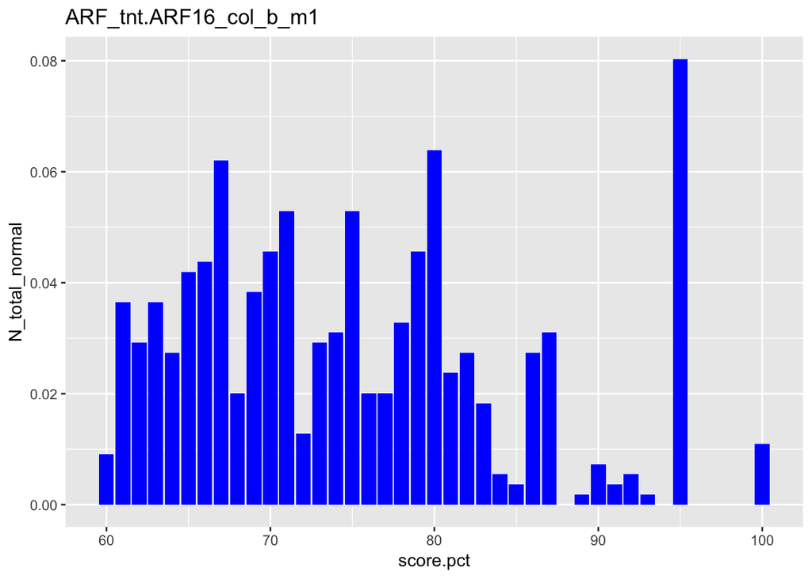

```r
# [1] "ARF_tnt.ARF2_col_v31_m1" "ARF_tnt.ARF16_col_b_m1"  # TF (ARF16_col_b_m1) accumulates at the end of the gene


# ARF_tnt.ARF16_col_b_m1
test <- Brapa3_TF_results_homoeolog %>%
  filter(motif == "ARF_tnt.ARF16_col_b_m1") %>%
  select(score.pct) %>%
  mutate(score.pct = round(score.pct)) %>%
  group_by(score.pct) %>%
  mutate(N_total = n()) %>%
  ungroup() %>%
  unique() %>%
  mutate(N_total_normal = N_total/sum(N_total)) %>%
  arrange(desc(score.pct))

 # ARF_tnt.ARF2_col_v31_m11
test_1 <- Brapa3_TF_results_homoeolog %>%
  filter(motif == "ARF_tnt.ARF2_col_v31_m1") %>%
  select(score.pct) %>%
  mutate(score.pct = round(score.pct)) %>%
  group_by(score.pct) %>%
  mutate(N_total = n()) %>%
  ungroup() %>%
  unique() %>%
  mutate(N_total_normal = N_total/sum(N_total)) %>%
  arrange(desc(score.pct))


test %>%
  ggplot() +
  geom_col(aes(x = score.pct, y = N_total_normal), fill = "blue") +
  labs(title = "ARF_tnt.ARF16_col_b_m1")
```

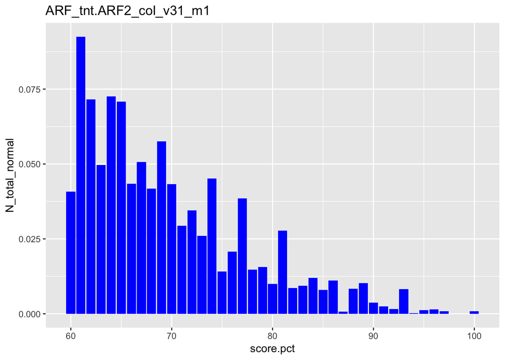

```r
test_1 %>%
  ggplot() +
  geom_col(aes(x = score.pct, y = N_total_normal), fill = "blue") +
  labs(title = "ARF_tnt.ARF2_col_v31_m1")
```

##### –General for all TFs—–

# Calculate “Norm_factor_1”, based on the number of promoters at particular distance/devided by total N of promoters in the data; This will be the same for all the TFs

# Normalisation should be calculated based on Promoter lenght, not distance_to_TSS!!

```r
n_col <- seq(0, 1500, by = 10)

Norm_promoters <- Brapa3_TF_results_homoeolog %>%
  select(gene_id, promoter_width) %>%
  mutate(promoter_width = round(promoter_width, -1)) %>%
  unique() %>% group_by(promoter_width) %>%
  mutate(N = n()) %>%
  ungroup() %>%
  arrange(N) %>%
  select(-gene_id) %>% unique() %>%
  right_join(., data.frame("promoter_width" = n_col), by = "promoter_width") %>%
  mutate_all(list(~replace(., is.na(.), 0)))

list_promoters <- Norm_promoters$promoter_width
# mutate(Norm_promoters, Norm_factor_1 =  unlist(lapply(list_promoters, function(x) filter(., promoter_width >= x ) %>% summarise(sum(N))))/sum(N))

Norm_promoters_factor1 <- Norm_promoters %>%
  mutate(Norm_factor_1 = unlist(lapply(list_promoters, function(x) filter(., promoter_width >= x ) %>%
  summarise(sum(N))))/sum(N)) %>%
  arrange(desc(promoter_width)) %>%
  select(.,-N)

Norm_factor_1 <- Norm_promoters_factor1$Norm_factor_1
```

## Plot disribution of “promoter_width” and “Norm_factor_1”

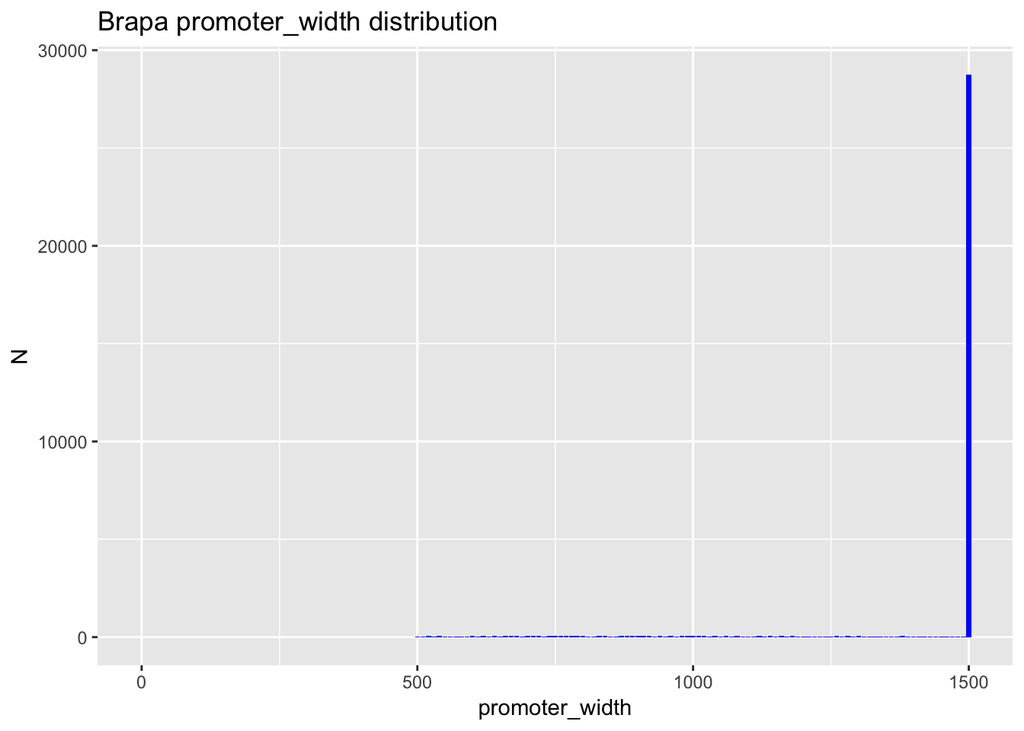

```r
p1 <- Norm_promoters %>%
  ggplot() +
  geom_col(aes(x = promoter_width, y = N), fill = "blue") +
  labs(title =  "Brapa promoter_width distribution")


p2 <- Norm_promoters_factor1 %>%
  ggplot() +
  geom_col(aes(x = promoter_width, y = Norm_factor_1), fill = "blue") +
  labs(title =  "Brapa Norm_factor_1 distribution")

p1
```

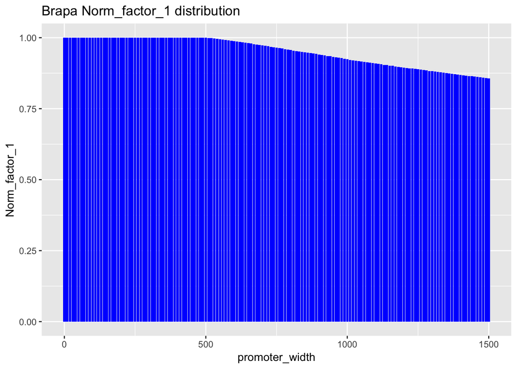

```r
p2
```

```r
#ggsave("Plots/Brapa_promoters_analysis_distance/Brapa_promoter_width_nomalisation_distribution.jpg", marrangeGrob(grobs = list(p1, p2), nrow = 2, ncol = 1))
rm(p1, p2)
```

##### ——–Specific for each TF————–

# *ARF_tnt.ARF16_col_b_m1*

# Create *“Expected_grid”* (distribution of score.pct what will be the same at any distance, and will be equal to the total distribution of all TF binding sites)

## Calculate the number of TF_binding sites with particular score.pct at all the distanses from TSS

```r
TF_motif <- "ARF_tnt.ARF16_col_b_m1"

score_pct_distribution <- Brapa3_TF_results_homoeolog %>%
  filter(motif == TF_motif) %>%
  select(score.pct) %>%
  mutate(score.pct = round(score.pct)) %>%
  group_by(score.pct) %>%
  mutate(N_total = n()) %>%
  ungroup() %>%
  unique() %>%
  mutate(N_total_normal = N_total/sum(N_total)) %>%
  arrange(desc(score.pct))
```

## Empty matrix for “Expected grid”

```r
n_rows <- min(round(score_pct_distribution$score.pct)):max(round(score_pct_distribution$score.pct))
n_col <- seq(0, 1500, by = 10)

Expected_grid_empty <-as.data.frame(matrix(, length(n_rows), length(n_col), dimnames=list(as.character(n_rows), as.character(n_col))))
```

## Fill “Expected grid” with scores.pct

```r
Expected_grid <- Expected_grid_empty %>%
  rownames_to_column(., var = "rowname") %>%
  mutate(.,rowname = as.numeric(rowname)) %>%
  left_join(., score_pct_distribution, by = c("rowname" = "score.pct")) %>%
  mutate_at(.vars = vars(-rowname, -N_total, -N_total_normal), .funs = list(~c(N_total_normal))) %>%
  mutate_at(vars(-rowname, -N_total, -N_total_normal), list(~replace(., is.na(.), 0))) %>%
  select(-N_total, -N_total_normal)
```

# Calculate “Norm_factor_2” for each TF to bring sum of values in Expected_grid to be 1

```r
Norm_factor_2 <- as_tibble(t(t(select(Expected_grid, -rowname))*Norm_factor_1)) %>%
  mutate(sum = rowSums(.)) %>%
select(.,sum) %>% sum()
```

## normalise “Expected_grid” by “Norm_factor_1” and “Norm_factor_2”

```r
Expected_grid_norm <- as_tibble(t(t(select(Expected_grid, -rowname))*Norm_factor_1)) %>%
   mutate_all(funs((. / Norm_factor_2))) %>%
  mutate(.,"rowname" = n_rows) %>%
  column_to_rownames(var="rowname")
# Check that the sum of all expected values is equal to 1
Expected_grid_norm %>%
mutate(sum = rowSums(.)) %>%
select(.,sum) %>% sum() == 1
```

```
## [1] TRUE
```

# Create *“Observed_grid”* (distribution of score.pct what were observed at any distance, for particular gene; nomalised by total Number of binding sites for this TF)

## Calculate the number of TF_binding sites with particular score.pct

```r
Observed_grid <- Brapa3_TF_results_homoeolog %>%
  filter(motif == TF_motif) %>%
  select(score.pct, distance_to_TSS) %>%
  mutate(score.pct = round(score.pct), distance_to_TSS = round(distance_to_TSS, -1)) %>%
  group_by(score.pct, distance_to_TSS) %>%
  mutate(N_score_distance = n()) %>%
  ungroup() %>%
  unique() %>%
  mutate(N_sd_norm = N_score_distance/sum(N_score_distance)) %>%
  arrange(desc(score.pct)) %>%
  select(., -N_score_distance) %>%
  right_join(., data.frame("distance_to_TSS" = n_col), by = "distance_to_TSS") %>%
  spread(., key = distance_to_TSS, value = N_sd_norm) %>%
  right_join(., data.frame("score.pct" = n_rows), by = "score.pct") %>%
  mutate_all(list(~replace(., is.na(.), 0))) %>%
  column_to_rownames(., var = "score.pct")

Observed_grid %>%
mutate(sum = rowSums(.)) %>%
select(.,sum) %>% sum() == 1
```

```
## [1] TRUE
```

# Calculate MSE and RMSE between Observed and Expected:

```r
MSE <- (Observed_grid - Expected_grid_norm)^2 %>%
              mutate(sum = rowSums(.)) %>%
              select(.,sum) %>% sum()
RMSE <- sqrt(
            ((Observed_grid - Expected_grid_norm)^2 %>%
              mutate(sum = rowSums(.)) %>%
              select(.,sum) %>% sum())/
              (length(n_rows)*length(n_col))
            )

MSE
```

```
## [1] 0.0019797
```

```r
RMSE
```

```
## [1] 0.0005654826
```

```r
# [1] 0.0019797
# [1] 0.0005654826
```

# Calculate the Overlape between “Predicted” and “Observed” values, by choosing the “min” value from both and sum all of the values.

## if sum is closed to 1, there is no difference between the distributions of probabilities for “Observed” and “Expected”

```r
Overlap_Observed_Expected <- Observed_grid %>% rownames_to_column("score.pct") %>%
  gather("distance_to_TSS", "Observed", -score.pct) %>%
  left_join(.,
            (Expected_grid_norm %>% rownames_to_column("score.pct") %>%
              gather("distance_to_TSS", "Expected", -score.pct)),
  by = c("score.pct", "distance_to_TSS")) %>%
  mutate(min_score = pmin(Observed, Expected )) %>%
  summarise_at(vars(min_score), funs(sum))

Overlap_Observed_Expected
```

```
##   min_score
## 1 0.1369796
```

```r
# 0.1369796
```

### Plot heatmaps

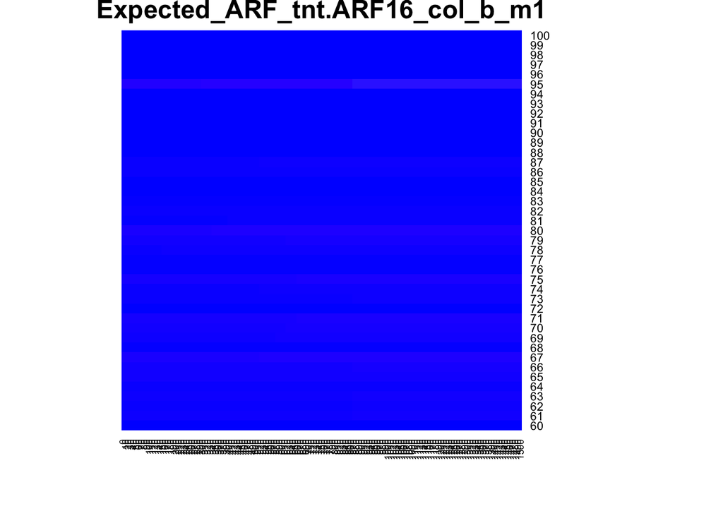

```r
# pdf("Plots/Brapa_promoters_analysis_distance/ARF_tnt.ARF16_col_b_m1_scores_pct_vs_distance_scaled.pdf")
# par(cex.main=1)
# p1 <-
heatmap(as.matrix(Expected_grid_norm),
                          Rowv = NA,
                          Colv = NA,
                          scale = "none",
                          col = colorRampPalette(c("blue","white", "red"))(n = 100),
                          breaks=seq(0,0.005,length.out=101),
                          #labRow=NA,
                          #labCol=column_names,
                          main="Expected_ARF_tnt.ARF16_col_b_m1",
                          #RowSideColors = brewer_par[data_matrix_variable$cluster],
                          #ColSideColors = hclust_columns$ColSideColors_arg,
                          #margins = c(12, 2)
 )
```

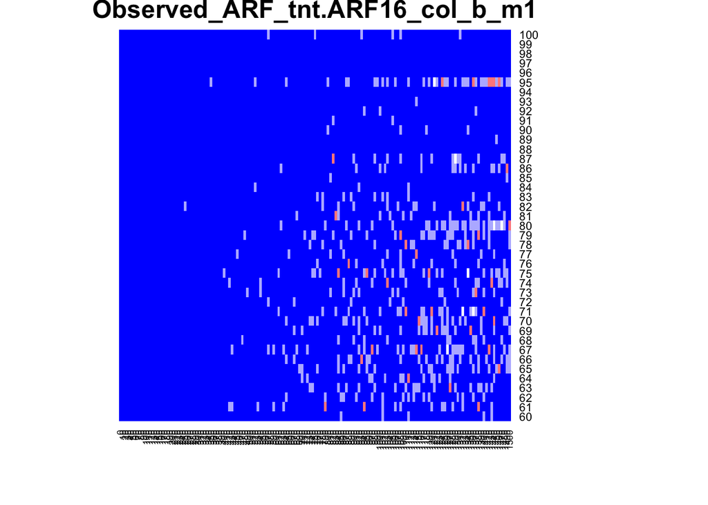

```r
# p2 <-
heatmap(as.matrix(Observed_grid),
                          Rowv = NA,
                          Colv = NA,
                          scale = "none",
                          col = colorRampPalette(c("blue","white", "red"))(n = 100),
                          breaks=seq(0,0.005,length.out=101),
                          #labRow=NA,
                          #labCol=column_names,
                          main="Observed_ARF_tnt.ARF16_col_b_m1",
                          #RowSideColors = brewer_par[data_matrix_variable$cluster],
                          #ColSideColors = hclust_columns$ColSideColors_arg,
                          #margins = c(12, 2)
 )
```

```r
# dev.off()
#
#
# p1
# p2
#
# rm(p1, p2)
```

### Plot heatmaps

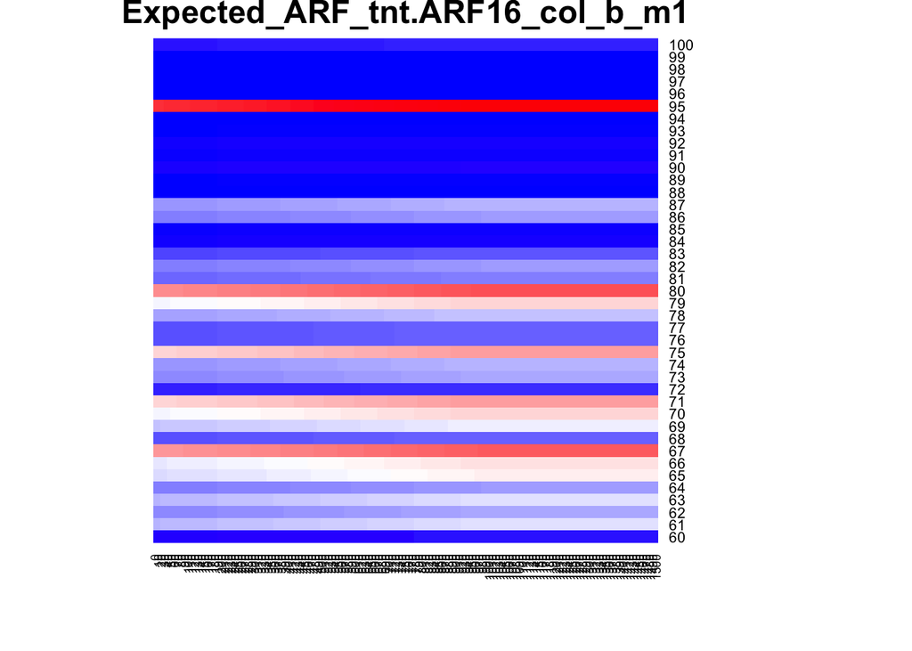

```r
# pdf("Plots/Brapa_promoters_analysis_distance/ARF_tnt.ARF16_col_b_m1_scores_pct_vs_distance_scaled.pdf")
# par(cex.main=1)
# p1 <-
heatmap(as.matrix(Expected_grid_norm),
                          Rowv = NA,
                          Colv = NA,
                          scale = "none",
                          col = colorRampPalette(c("blue","white", "red"))(n = 100),
                          #breaks=seq(0,0.005,length.out=101),
                          #labRow=NA,
                          #labCol=column_names,
                          main="Expected_ARF_tnt.ARF16_col_b_m1",
                          #RowSideColors = brewer_par[data_matrix_variable$cluster],
                          #ColSideColors = hclust_columns$ColSideColors_arg,
                          #margins = c(12, 2)
 )
```

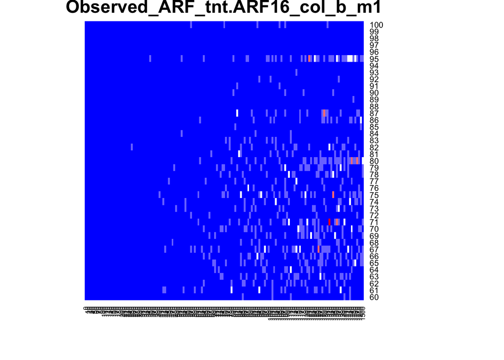

```r
# p2 <-
heatmap(as.matrix(Observed_grid),
                          Rowv = NA,
                          Colv = NA,
                          scale = "none",
                          col = colorRampPalette(c("blue","white", "red"))(n = 100),
                          #breaks=seq(0,0.005,length.out=101),
                          #labRow=NA,
                          #labCol=column_names,
                          main="Observed_ARF_tnt.ARF16_col_b_m1",
                          #RowSideColors = brewer_par[data_matrix_variable$cluster],
                          #ColSideColors = hclust_columns$ColSideColors_arg,
                          #margins = c(12, 2)
 )
```

```r
# dev.off()
#
#
# p1
# p2
#
# rm(p1, p2)
```

```r
rm(TF_motif, score_pct_distribution, n_rows, n_col, Expected_grid, Expected_grid_empty, Expected_grid_norm, Observed_grid, list_promoters, Norm_factor_2, MSE, RMSE, Overlap_Observed_Expected)
```

##### ——-“ARF_tnt.ARF2_col_v31_m1”———–

# Create Expected_grid (distribution of score.pct what will be the same at any distance, and will be equal to the total distribution of all TF binding sites)